# chapter5.Rmd

nuriiar

2022-12-06

#PCA and MCA

```r
#unpacking the libraries
library(dplyr)
```

```r
library(corrplot)
library(GGally)
library(tidyverse)
library(ggplot2)
library(FactoMineR)
set.seed(1)
#reading the data
human <- read.csv("human.csv", header = T, row.names = 1)

colnames(human)
```

```
## [1] "Edu2.FM"   "Labo.FM"   "Life.Exp"  "Edu.Exp"   "GNI"       "Mat.Mor"
## [7] "Ado.Birth" "Parli.F"
```

```r
str(human)
```

```
## 'data.frame':    155 obs. of  8 variables:
##  $ Edu2.FM  : num  1.007 0.997 0.983 0.989 0.969 ...
##  $ Labo.FM  : num  0.891 0.819 0.825 0.884 0.829 ...
##  $ Life.Exp : num  81.6 82.4 83 80.2 81.6 80.9 80.9 79.1 82 81.8 ...
##  $ Edu.Exp  : num  17.5 20.2 15.8 18.7 17.9 16.5 18.6 16.5 15.9 19.2 ...
##  $ GNI      : num  65 42.3 56.4 44 45.4 ...
##  $ Mat.Mor  : int  4 6 6 5 6 7 9 28 11 8 ...
##  $ Ado.Birth: num  7.8 12.1 1.9 5.1 6.2 3.8 8.2 31 14.5 25.3 ...
##  $ Parli.F  : num  39.6 30.5 28.5 38 36.9 36.9 19.9 19.4 28.2 31.4 ...
```

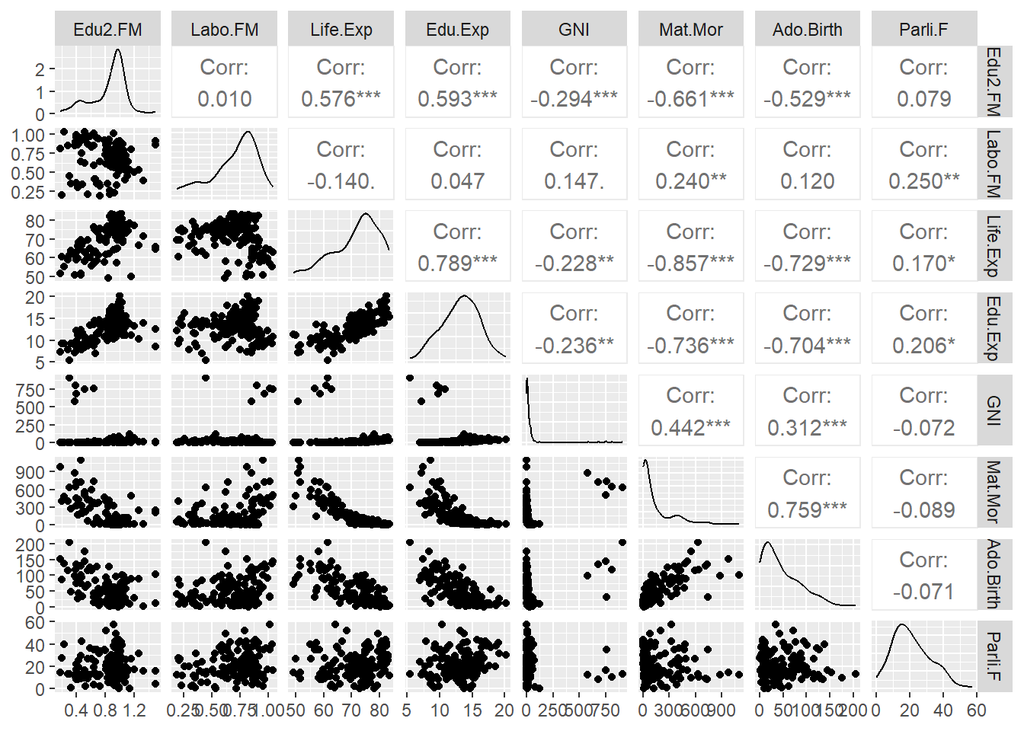

```r
#exploring the relations
ggpairs(human)
```

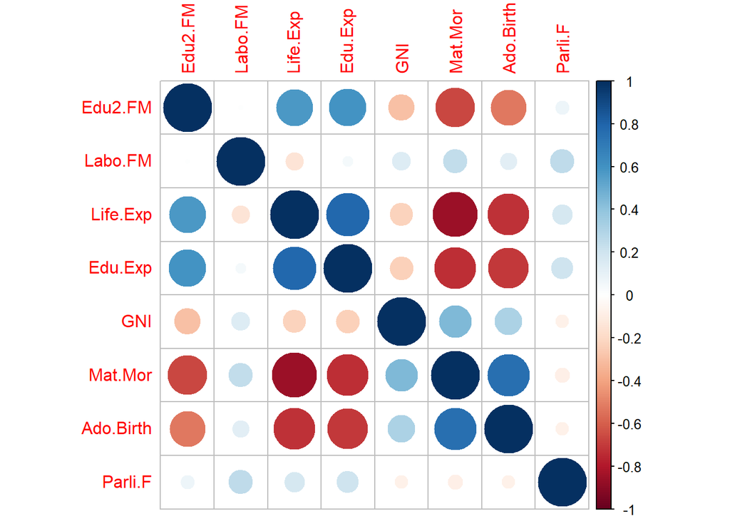

```r
cor(human) %>% corrplot()
```

The data is human development indices from the UN, with multiple measures. For more on data and the indices see: https://hdr.undp.org/data-center/human-development-index#/indicies/HDI Correlation plot reveals interesting trends in relations of the variables: for example, life expectancy at birth and expected years of schooling have a strong linear positive correlation.

```r
#PCA
pca_human <- prcomp(human)
summary(pca_human)
```

```
## Importance of components:
##                            PC1      PC2      PC3      PC4     PC5     PC6
## Standard deviation     227.566 121.2798 26.48071 11.47526 3.89773 1.60859
## Proportion of Variance   0.769   0.2184  0.01041  0.00196 0.00023 0.00004
## Cumulative Proportion    0.769   0.9874  0.99778  0.99974 0.99996 1.00000
##                           PC7    PC8
## Standard deviation     0.1915 0.1598
## Proportion of Variance 0.0000 0.0000
## Cumulative Proportion  1.0000 1.0000
```

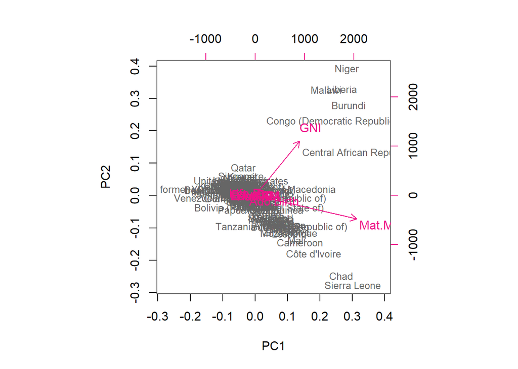

```r
biplot(pca_human, choices = 1:2, cex = c(0.8, 1), col = c("grey40", "deeppink2"))
```

In unstandardised data, we can see the summary of PCA. There, we can clearly see, that first two principle components already explain 98% of the variance, meaning only those two dimensions are important to study.

```r
help(biplot)
```

```
## starting httpd help server ... done
```

```r
#PCA for standardised data
human_std <- scale(human)
pca_human_std <- prcomp(human_std)
summary(pca_human_std)
```

```
## Importance of components:
##                           PC1    PC2    PC3     PC4     PC5     PC6     PC7
## Standard deviation     1.9970 1.1465 0.9439 0.85645 0.69002 0.53246 0.46511
## Proportion of Variance 0.4985 0.1643 0.1114 0.09169 0.05952 0.03544 0.02704
## Cumulative Proportion  0.4985 0.6628 0.7742 0.86585 0.92536 0.96080 0.98784
##                            PC8
## Standard deviation     0.31184
## Proportion of Variance 0.01216
## Cumulative Proportion  1.00000
```

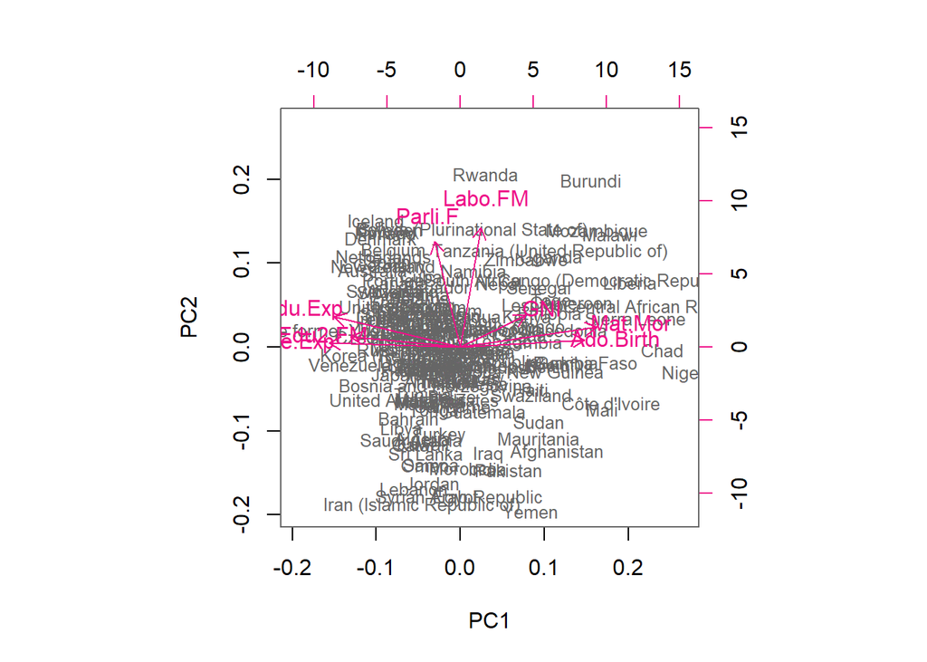

```r
biplot(pca_human_std, choices = 1:2, cex = c(0.8, 1), col = c("grey40", "deeppink2"))
```

According to the summary of a PCA on standardised data, there are more dimensions that are important comparing to unstandardised model, with the first one explaining 49% of variation and the 2 to 4 each explaining about 10-15 % of the variance. Yet, the biplot extracts only two dimensions as 4 or 5 dimensional representation is hard for human imagination and impossible to draw. It is reasonable to analyse only first two or three dim, so we take components 1 and 2. PC1 probably represents the overall health in the countries, in general countries with worse life exp and mortality would be positioned further from 0 value. The PC2 might represent overall equality or gender equality with most unequal countries being positioned lower in the chart (mostly muslim states). The unstandardised chart is too difficult to see, what countries are in the middle and why, need to rescale to make it more analysable. Tea data

```r
tea <- read.csv("https://raw.githubusercontent.com/KimmoVehkalahti/Helsinki-Open-Data-Science/master/datasets/tea.csv", stringsAsFactors = TRUE)
keep1 <- c("Tea", "How", "how", "sugar", "where", "lunch")
tea_time <- select(tea, one_of(keep1))
head(tea_time)
```

```
##         Tea   How     how    sugar       where     lunch
## 1     black alone tea bag    sugar chain store Not.lunch
## 2     black  milk tea bag No.sugar chain store Not.lunch
## 3 Earl Grey alone tea bag No.sugar chain store Not.lunch
## 4 Earl Grey alone tea bag    sugar chain store Not.lunch
## 5 Earl Grey alone tea bag No.sugar chain store Not.lunch
## 6 Earl Grey alone tea bag No.sugar chain store Not.lunch
```

```r
#pivot_longer(tea_time, cols = everything()) %>% ggplot(aes(value)) + facet_wrap("name", scales = "free")
mca <- MCA(tea_time, graph = FALSE)
summary(mca)
```

```
##
## Call:
## MCA(X = tea_time, graph = FALSE)
##
##
## Eigenvalues
##                        Dim.1   Dim.2   Dim.3   Dim.4   Dim.5   Dim.6   Dim.7
## Variance               0.279   0.261   0.219   0.189   0.177   0.156   0.144
## % of var.             15.238  14.232  11.964  10.333   9.667   8.519   7.841
## Cumulative % of var.  15.238  29.471  41.435  51.768  61.434  69.953  77.794
##                        Dim.8   Dim.9  Dim.10  Dim.11
## Variance               0.141   0.117   0.087   0.062
## % of var.              7.705   6.392   4.724   3.385
## Cumulative % of var.  85.500  91.891  96.615 100.000
##
## Individuals (the 10 first)
##                       Dim.1    ctr   cos2    Dim.2    ctr   cos2    Dim.3
## 1                  | -0.298  0.106  0.086 | -0.328  0.137  0.105 | -0.327
## 2                  | -0.237  0.067  0.036 | -0.136  0.024  0.012 | -0.695
## 3                  | -0.369  0.162  0.231 | -0.300  0.115  0.153 | -0.202
## 4                  | -0.530  0.335  0.460 | -0.318  0.129  0.166 |  0.211
## 5                  | -0.369  0.162  0.231 | -0.300  0.115  0.153 | -0.202
## 6                  | -0.369  0.162  0.231 | -0.300  0.115  0.153 | -0.202
## 7                  | -0.369  0.162  0.231 | -0.300  0.115  0.153 | -0.202
## 8                  | -0.237  0.067  0.036 | -0.136  0.024  0.012 | -0.695
## 9                  |  0.143  0.024  0.012 |  0.871  0.969  0.435 | -0.067
## 10                 |  0.476  0.271  0.140 |  0.687  0.604  0.291 | -0.650
##                       ctr   cos2
## 1                   0.163  0.104 |
## 2                   0.735  0.314 |
## 3                   0.062  0.069 |
## 4                   0.068  0.073 |
## 5                   0.062  0.069 |
## 6                   0.062  0.069 |
## 7                   0.062  0.069 |
## 8                   0.735  0.314 |
## 9                   0.007  0.003 |
## 10                  0.643  0.261 |
##
## Categories (the 10 first)
```

[output cut: 16 more lines]

```
## lemon                3.226 |   1.329  14.771   0.218   8.081 |
## milk                 2.422 |   0.013   0.003   0.000   0.116 |
## other                5.534 |  -2.524  14.526   0.197  -7.676 |
## tea bag             -6.941 |  -0.065   0.183   0.006  -1.287 |
## tea bag+unpackaged  11.956 |   0.019   0.009   0.000   0.226 |
## unpackaged          -6.482 |   0.257   0.602   0.009   1.640 |
##
## Categorical variables (eta2)
##                      Dim.1 Dim.2 Dim.3
## Tea                | 0.126 0.108 0.410 |
## How                | 0.076 0.190 0.394 |
## how                | 0.708 0.522 0.010 |
## sugar              | 0.065 0.001 0.336 |
## where              | 0.702 0.681 0.055 |
## lunch              | 0.000 0.064 0.111 |
```

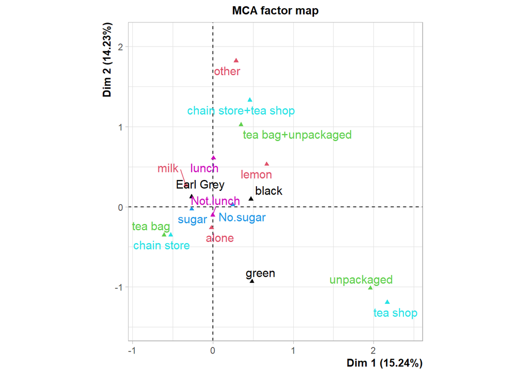

```r
plot(mca, invisible=c("ind"),habillage = "quali")
```

From the summary of MCA on tea data, we can see that the first 3 loaded 41% of inertia meaning that they only explain 41% of the total variance in the chosen variables. This shows that the variables do not stick together that well, and there is no clear dimension or factor explaining why values vary in the variables. This may be due to the fact that the MCA does not allow rotation, and might be not suitable for analysis of many strong dimensions. Yet, from the plot we see that a lot of values are graphically proximate to each other, values such as earl gray, black, not.lunch, alone, no.sugar lunch, lemon, milk are quite close considering both x and y axes.